# OTU Clustering

Load libraries

```r
source("../General/rmb_functions.R")
source("../General/parameters.R")
library(factoextra)
library(cluster)
library(ggtree)
library(cowplot)
library(tidyverse)
```

Load data

```r
otu <- readRDS("../Data/otu_pers.RDS")
map <- readRDS("../Data/drought_map.RDS")
rs.fc <- readRDS("../Data/rs_shlfc.RDS")
es.fc <- readRDS("../Data/es_shlfc.RDS")
tax <- readRDS("../Data/tax.RDS") %>%
  mutate(PhyClass2 = fct_recode(PhyClass2, "Low abundance" = "other"))
```

Remove RF training set from mapping file. Subset mapping files for each compartment

```r
map <- filter(map, Treatment2 != "WC_TRN")
rs.map <- filter(map, Compartment == "RS")
es.map <- filter(map, Compartment == "ES")
```

Get the relative abundances, reformat, and subset

```r
otu <- rel_ab(otu)

rs.otu.tidy <- tidy_otu(otu) %>%
  mutate(Count = Count/100) %>%
  filter(SampleID %in% rs.map$SampleID) %>%
  filter(!is.na(Count))

es.otu.tidy <- tidy_otu(otu) %>%
  mutate(Count = Count/100) %>%
  filter(SampleID %in% es.map$SampleID) %>%
  filter(!is.na(Count))
```

Get significant OTUs for each set

```r
rs.sig <- rs.fc %>%
  select(-Day) %>%
  separate(Contrast, c("Treatment", "Time"), sep = "\\.") %>%
  filter(Treatment != "WC_TRN") %>%
  filter(!is.na(p.adjusted)) %>%
  ungroup() %>%
  mutate(p.adjusted2 = p.adjust(p.value, method = "fdr")) %>%
  ungroup() %>%
  filter(p.adjusted2 < 0.05)

es.sig <- es.fc %>%
  select(-Day) %>%
  separate(Contrast, c("Treatment", "Time"), sep = "\\.") %>%
  filter(Treatment != "WC_TRN") %>%
  filter(!is.na(p.adjusted)) %>%
  ungroup() %>%
  mutate(p.adjusted2 = p.adjust(p.value, method = "fdr")) %>%
  ungroup() %>%
  filter(p.adjusted2 < 0.05)
```

For visualization purposes, generate a data frame with the range of drought stress time points for each treatment

```r
trt.lines <- data.frame(Treatment = c("DS1", "DS2", "DS3"),
                        Treatment2 = c("DS1", "DS2", "DS3"),
                        Contrast = c("WC vs DS1", "WC vs DS2", "WC vs DS3"),
                        IniTreatment = c(4.5, 4.5, 4.5),
                        EndTreatment = c(5.5, 6.5, 7.5))
```

Evaluate the distribution of significant OTUs across treatments and collection time points.

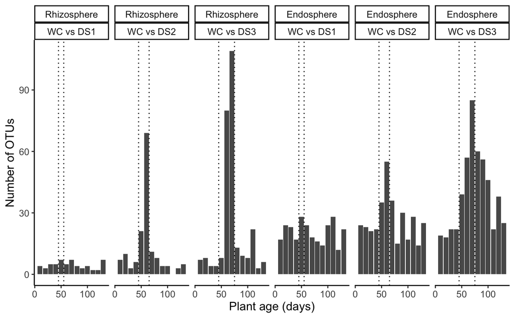

```r
all.sig <- rbind(mutate(rs.sig, Compartment = "RS"),
                 mutate(es.sig, Compartment = "ES"))

dao.p <- all.sig %>%
  mutate(Contrast = case_when(Treatment == "D1" ~ "WC vs DS1",
                              Treatment == "D2" ~ "WC vs DS2",
                              Treatment == "D3" ~ "WC vs DS3")) %>%
  mutate(Compartment = ifelse(Compartment == "RS", "Rhizosphere", "Endosphere")) %>%
  mutate(Compartment = fct_relevel(Compartment, "Rhizosphere")) %>%
  ggplot(aes(as.numeric(Time) * 10)) +
  geom_bar() +
  geom_vline(data = trt.lines, aes(xintercept = IniTreatment * 10), linetype = 3) +
  geom_vline(data = trt.lines, aes(xintercept = EndTreatment * 10), linetype = 3) +
  scale_fill_manual(values = resp.pal) +
  xlab("Plant age (days)") +
  ylab("Number of OTUs") +
  facet_grid(. ~ Compartment + Contrast) +
  theme_classic() +
  theme(text = element_text(size = 12))

dao.p
```

Generate supplementary table with all differentially abundant OTUs.

```r
time.age <- map %>%
  group_by(Time, Age) %>%
  count() %>%
  ungroup() %>%
  select(-n)

dao.supp <- all.sig %>%
  mutate(Time = as.integer(Time)) %>%
  mutate(Contrast = paste("WC_vs_", Treatment, sep = "")) %>%
  select(-Treatment) %>%
  inner_join(time.age, by = "Time") %>%
  select(Compartment, Contrast, Time, Age, everything()) %>%
  select(-p.adjusted) %>%
  rename("p.adjusted" = "p.adjusted2")

write.table(dao.supp, "../Tables/dao_updated.tsv", sep = "\t", quote = F, row.names = F)
```

Define the clustering methods to test

```r
m <- c( "average", "single", "complete", "ward")
names(m) <- c( "average", "single", "complete", "ward")
```

RHIZOSPHERE z-transform relative abundances; calculate the mean z-score for each treatment, and time point combination; generate a matrix for hierarchical clustering

```r
rs.zs.tidy <- rs.otu.tidy %>%
  inner_join(map, by = "SampleID") %>%
  filter(OTU_ID %in% rs.sig$OTU_ID) %>%
  group_by(OTU_ID) %>%
  mutate(zscore = (Count - mean(Count))/sd(Count)) %>%
  group_by(Treatment, Time, OTU_ID, Age) %>%
  summarise(MeanZS = mean(zscore)) %>%
  ungroup()
rs.fc.mtx <- rs.fc %>%
  separate(Contrast, c("Treatment2", "Time"), sep = "\\.") %>%
  mutate(Treatment = Treatment2) %>%
  filter(Treatment2 != "WC_TRN") %>%
  filter(OTU_ID %in% rs.sig$OTU_ID) %>%
  mutate(Contrast = paste(Treatment2, Time, sep = ".")) %>%
  select(Contrast, OTU_ID, estimate) %>%
  spread(key = Contrast, value = estimate)
rs.fc.mtx <- as.data.frame(rs.fc.mtx)
rownames(rs.fc.mtx) <- rs.fc.mtx$OTU_ID
rs.fc.mtx <- rs.fc.mtx[,-1]
```

Choose a clustering method and number of clusters Approach based on: https://uc-r.github.io/hc_clustering

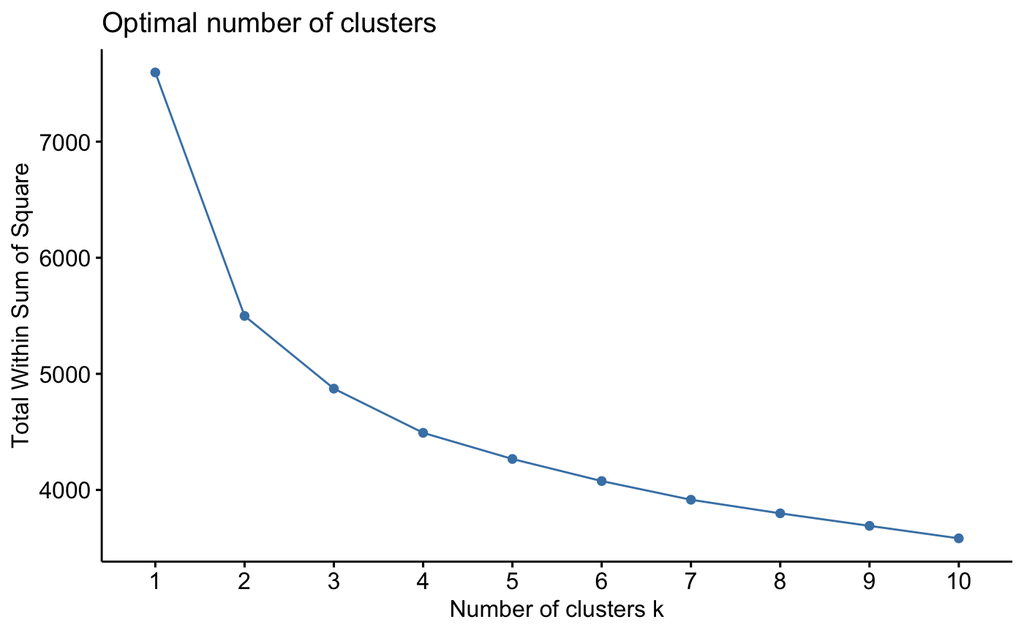

```r
# See what values of k might be worth testing
fviz_nbclust(rs.fc.mtx, FUN = hcut, method = "wss")
```

```r
# See which method gets you the best clustering
rs.ac <- function(x) {
  agnes(rs.fc.mtx, method = x)$ac
}
map_dbl(m, rs.ac)
```

```
  average    single  complete      ward
0.6332243 0.6018716 0.7824292 0.9347704
```

It seems the elbow is around 3 so test 2:4 by changing the value of the rs.k variable Perform hierarchical clustering and get the set of clusters and order of OTUs

```r
rs.k <- 4

rs.dist <- dist(as.matrix(rs.fc.mtx))
rs.clust <- hclust(rs.dist, method = "ward.D")
rs.ord.names <- rs.clust$labels[rs.clust$order]
rs.ord <- data.frame(OTU_ID = rs.ord.names, order = 1:length(rs.ord.names))

rs.cut <- cutree(rs.clust[c(1,2,4)], k = rs.k)
rs.ord$Cluster <- as.factor(rs.cut[rs.ord$OTU_ID])

rs.ord <- rs.ord %>%
  mutate(Cluster = paste("C", Cluster, sep = "")) %>%
  group_by(Cluster) %>%
  mutate(nOTU = n()) %>%
  ungroup() %>%
  mutate(Cluster2 = paste(Cluster, " (", nOTU, " OTUs)", sep = ""))
```

Visualize as heatmap

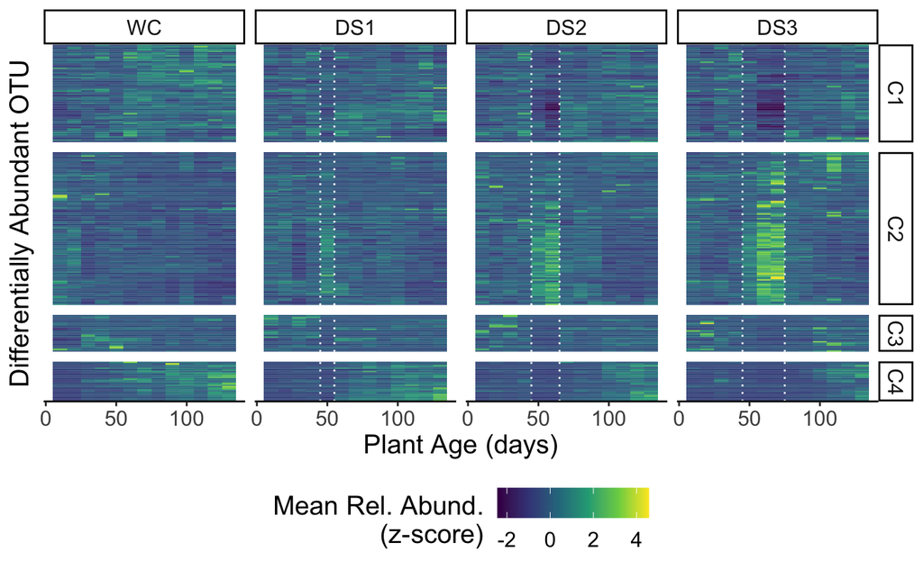

```r
### with relative abundances

rs.hm.p <- rs.zs.tidy %>%
  inner_join(rs.ord, by = "OTU_ID") %>%
  mutate(Treatment = str_replace(Treatment, "D", "DS")) %>%
  mutate(Treatment = fct_relevel(Treatment, "WC")) %>%
  ggplot(aes(Time*10, reorder(OTU_ID, order), fill = MeanZS)) +
  geom_tile() +
  geom_vline(data = trt.lines, aes(xintercept = IniTreatment*10), linetype = 3, color = "white") +
  geom_vline(data = trt.lines, aes(xintercept = EndTreatment*10), linetype = 3, color = "white") +
  scale_fill_viridis_c(name = "Mean Rel. Abund.\n(z-score)") +
  ylab("Differentially Abundant OTU") +
  xlab("Plant Age (days)") +
  facet_grid(Cluster ~ Treatment, scales = "free", space = "free") +
  theme_classic() +
  theme(text = element_text(size = 15),
        axis.text.y = element_blank(),
        axis.ticks.y = element_blank(),
        axis.line.y = element_blank(),
        legend.position = "bottom",
        legend.title.align = 1)

rs.hm.p
```

```
Unknown levels in `f`: WC
```

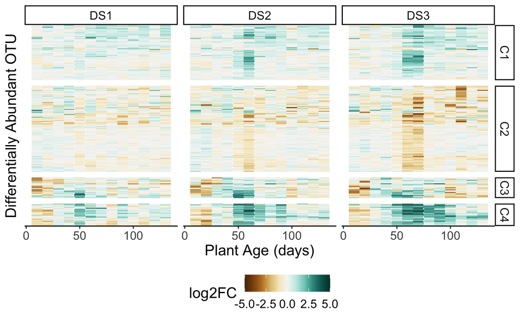

```r
#### with log fold changes.

rs.fc %>%
  separate(Contrast, c("Treatment2", "Time"), sep = "\\.") %>%
  mutate(Treatment = Treatment2) %>%
  filter(Treatment2 != "WC_TRN") %>%
  mutate(Time = as.numeric(Time)) %>%
  inner_join(rs.ord, by = "OTU_ID") %>%
  mutate(Treatment = str_replace(Treatment, "D", "DS")) %>%
  mutate(Treatment = fct_relevel(Treatment, "WC")) %>%
  mutate(estimate2 = ifelse(abs(estimate) >5, 5 * sign(estimate), estimate)) %>%
  ggplot(aes(Time*10, reorder(OTU_ID, order), fill = estimate2)) +
  geom_tile() +
  geom_vline(data = trt.lines, aes(xintercept = IniTreatment*10), linetype = 3, color = "white") +
  geom_vline(data = trt.lines, aes(xintercept = EndTreatment*10), linetype = 3, color = "white") +
  #scale_fill_viridis_c(name = "Mean Rel. Abund.\n(z-score)") +
  scale_fill_gradientn(name = "log2FC",
                       colors = RColorBrewer::brewer.pal(11, "BrBG")) +
  #scale_fill_distiller(palette = "Spectral") +
  ylab("Differentially Abundant OTU") +
  xlab("Plant Age (days)") +
  facet_grid(Cluster ~ Treatment, scales = "free", space = "free") +
  theme_classic() +
  theme(text = element_text(size = 15),
        axis.text.y = element_blank(),
        axis.ticks.y = element_blank(),
        axis.line.y = element_blank(),
        legend.position = "bottom",
        legend.title.align = 1)
```

Visualize the aggregated relative abundances

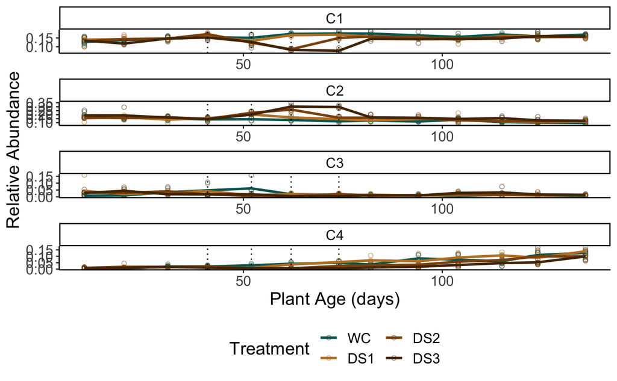

```r
rs.agg.ra <- rs.otu.tidy %>%
  inner_join(rs.ord, by = "OTU_ID") %>%
  group_by(Cluster, SampleID) %>%
  summarise(AggRelAb = sum(Count)) %>%
  inner_join(rs.map, by = "SampleID") %>%
  ungroup() %>%
  mutate(Treatment = str_replace(Treatment, "D", "DS")) %>%
  mutate(Treatment = fct_relevel(Treatment, "WC"))
rs.agg.means <- rs.agg.ra %>%
  group_by(Treatment, Compartment, Time, Cluster) %>%
  mutate(MeanRelAb = mean(AggRelAb)) %>%
  ungroup()

rs.clstr.p <- rs.agg.ra %>%
  ggplot(aes(Age, AggRelAb, color = Treatment)) +
  geom_point(stat = "identity", position = "dodge", alpha = 0.5, shape = 1) +
  geom_line(data = rs.agg.means, aes(y = MeanRelAb), size = 1) +
  geom_vline(xintercept = ws.line, linetype = 3) +
  scale_color_manual(values = trt.pal, name = "Treatment") +
  guides(color = guide_legend(ncol = 2)) +
  ylab("Relative Abundance") +
  xlab("Plant Age (days)") +
  facet_wrap(~ Cluster, ncol = 1, scales = "free") +
  theme_classic() +
  theme(legend.position = "bottom",
        text = element_text(size = 15))

rs.clstr.p
```

ENDOSPHERE z-transform relative abundances, calculate the mean z-score for each treatment, and time point combination, generate a matrix for hierarchical clustering

```r
es.zs.tidy <- es.otu.tidy %>%
  inner_join(map, by = "SampleID") %>%
  filter(OTU_ID %in% es.sig$OTU_ID) %>%
  group_by(OTU_ID) %>%
  mutate(zscore = (Count - mean(Count))/sd(Count)) %>%
  group_by(Treatment, Time, OTU_ID, Age) %>%
  summarise(MeanZS = mean(zscore)) %>%
  ungroup()
es.fc.mtx <- es.fc %>%
  separate(Contrast, c("Treatment2", "Time"), sep = "\\.") %>%
  mutate(Treatment = Treatment2) %>%
  filter(Treatment2 != "WC_TRN") %>%
  filter(OTU_ID %in% es.sig$OTU_ID) %>%
  mutate(Contrast = paste(Treatment2, Time, sep = ".")) %>%
  select(Contrast, OTU_ID, estimate) %>%
  spread(key = Contrast, value = estimate)
es.fc.mtx <- as.data.frame(es.fc.mtx)
rownames(es.fc.mtx) <- es.fc.mtx$OTU_ID
es.fc.mtx <- es.fc.mtx[,-1]
```

Choose a clustering method and number of clusters

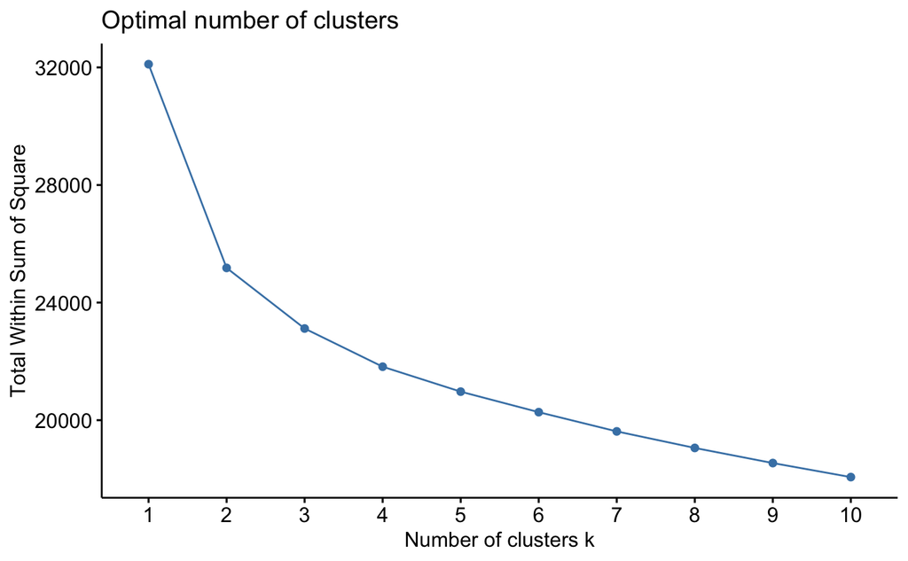

```r
# See what values of k might be worth testing
fviz_nbclust(es.fc.mtx, FUN = hcut, method = "wss")
```

```r
# See which method gets you the best clustering
es.ac <- function(x) {
  agnes(es.fc.mtx, method = x)$ac
}
map_dbl(m, es.ac)
```

```
  average    single  complete      ward
0.6346715 0.5660795 0.7600490 0.9194665
```

Perform hierarchical clustering and get the set of clusters and order of OTUs

```r
es.k <- 5

es.dist <- dist(as.matrix(es.fc.mtx))
es.clust <- hclust(es.dist, method = "ward.D")
es.ord.names <- es.clust$labels[es.clust$order]
es.ord <- data.frame(OTU_ID = es.ord.names, order = 1:length(es.ord.names))

es.cut <- cutree(es.clust[c(1,2,4)], k = es.k)
es.ord$Cluster <- as.factor(es.cut[es.ord$OTU_ID])

es.ord <- es.ord %>%
  mutate(Cluster = paste("C", Cluster, sep = "")) %>%
  group_by(Cluster) %>%
  mutate(nOTU = n()) %>%
  ungroup() %>%
  mutate(Cluster2 = paste(Cluster, " (", nOTU, " OTUs)", sep = ""))
```

Visualize as heatmap

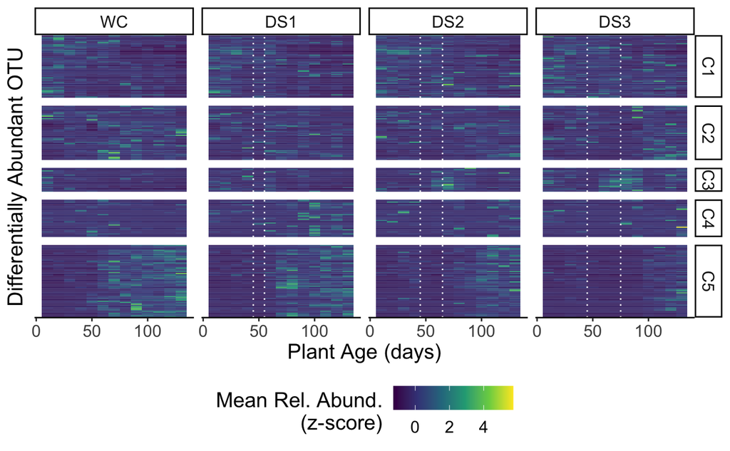

```r
### with relative abundances

es.hm.p <- es.zs.tidy %>%
  inner_join(es.ord, by = "OTU_ID") %>%
  mutate(Treatment = str_replace(Treatment, "D", "DS")) %>%
  mutate(Treatment = fct_relevel(Treatment, "WC")) %>%
  ggplot(aes(Time*10, reorder(OTU_ID, order), fill = MeanZS)) +
  geom_tile() +
  geom_vline(data = trt.lines, aes(xintercept = IniTreatment*10), linetype = 3, color = "white") +
  geom_vline(data = trt.lines, aes(xintercept = EndTreatment*10), linetype = 3, color = "white") +
  scale_fill_viridis_c(name = "Mean Rel. Abund.\n(z-score)") +
  #scale_fill_distiller(palette = "Spectral") +
  ylab("Differentially Abundant OTU") +
  xlab("Plant Age (days)") +
  facet_grid(Cluster ~ Treatment, scales = "free", space = "free") +
  theme_classic() +
  theme(text = element_text(size = 15),
        axis.text.y = element_blank(),
        axis.ticks.y = element_blank(),
        axis.line.y = element_blank(),
        legend.position = "bottom",
        legend.title.align = 1)

es.hm.p
```

```
Unknown levels in `f`: WC
```

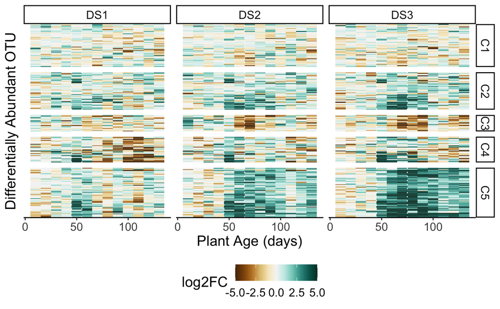

```r
### with log fold changes

es.fc %>%
  separate(Contrast, c("Treatment2", "Time"), sep = "\\.") %>%
  mutate(Treatment = Treatment2) %>%
  filter(Treatment2 != "WC_TRN") %>%
  mutate(Time = as.numeric(Time)) %>%
  inner_join(es.ord, by = "OTU_ID") %>%
  mutate(Treatment = str_replace(Treatment, "D", "DS")) %>%
  mutate(Treatment = fct_relevel(Treatment, "WC")) %>%
  mutate(estimate2 = ifelse(abs(estimate) >5, 5 * sign(estimate), estimate)) %>%
  ggplot(aes(Time*10, reorder(OTU_ID, order), fill = estimate2)) +
  geom_tile() +
  geom_vline(data = trt.lines, aes(xintercept = IniTreatment*10), linetype = 3, color = "white") +
  geom_vline(data = trt.lines, aes(xintercept = EndTreatment*10), linetype = 3, color = "white") +
  #scale_fill_viridis_c(name = "Mean Rel. Abund.\n(z-score)") +
  scale_fill_gradientn(name = "log2FC",
                       colors = RColorBrewer::brewer.pal(11, "BrBG")) +
  #scale_fill_distiller(palette = "Spectral") +
  ylab("Differentially Abundant OTU") +
  xlab("Plant Age (days)") +
  facet_grid(Cluster ~ Treatment, scales = "free", space = "free") +
  theme_classic() +
  theme(text = element_text(size = 15),
        axis.text.y = element_blank(),
        axis.ticks.y = element_blank(),
        axis.line.y = element_blank(),
        legend.position = "bottom",
        legend.title.align = 1)
```

Visualize the aggregated relative abundances

[figure not shown]

```r
es.agg.ra <- es.otu.tidy %>%
  inner_join(es.ord, by = "OTU_ID") %>%
  group_by(Cluster, SampleID) %>%
  summarise(AggRelAb = sum(Count)) %>%
  inner_join(es.map, by = "SampleID") %>%
  ungroup() %>%
  mutate(Treatment = str_replace(Treatment, "D", "DS")) %>%
  mutate(Treatment = fct_relevel(Treatment, "WC"))
es.agg.means <- es.agg.ra %>%
  group_by(Treatment, Compartment, Time, Cluster) %>%
  mutate(MeanRelAb = mean(AggRelAb)) %>%
  ungroup()

es.clstr.p <- es.agg.ra %>%
  ggplot(aes(Age, AggRelAb, color = Treatment)) +
  geom_point(stat = "identity", position = "dodge", alpha = 0.5, shape = 1) +
  geom_line(data = es.agg.means, aes(y = MeanRelAb), size = 1) +
  geom_vline(xintercept = ws.line, linetype = 3) +
  scale_color_manual(values = trt.pal, name = "Treatment") +
  guides(color = guide_legend(ncol = 2)) +
  ylab("Relative Abundance") +
  xlab("Plant Age (days)") +
  facet_wrap(~ Cluster, ncol = 1, scales = "free") +
  theme_classic() +
  theme(legend.position = "bottom",
        text = element_text(size = 15))

es.clstr.p
```

Merge endosphere and rhizosphere results

```r
all.ord <- rbind(mutate(rs.ord, Compartment = "RS"),
                 mutate(es.ord, Compartment = "ES"))
```

Generate a data frame with all clustering results, and label the interesting clusters for downstream analyses Generate a data frame with all the mean z-scores for plotting

```r
all.clust.summary <- rbind(mutate(rs.ord, Compartment = "RS"),
                           mutate(es.ord, Compartment = "ES")) %>%
  mutate(Cluster = paste(Compartment, Cluster, sep = "")) %>%
  filter(Cluster %in% c("RSC1", "RSC2", "RSC4", "ESC3", "ESC5")) %>%
  mutate(Trend = case_when(Cluster == "RSC1" ~ "Transient depletion",
                           Cluster == "RSC2" ~ "Transient enrichment",
                           Cluster == "RSC4" ~ "Persistent depletion",
                           Cluster == "ESC3" ~ "Semi-persistent enrichment",
                           Cluster == "ESC5" ~ "Persistent depletion"))

all.cluster.total <- all.clust.summary %>%
  group_by(Cluster, nOTU, Cluster2, Compartment, Trend) %>%
  count() %>%
  select(-n) %>%
  ungroup() %>%
  mutate(Compartment = fct_recode(Compartment,
                                  "Rhizosphere" = "RS",
                                  "Endosphere" = "ES")) %>%
  mutate(Compartment = fct_relevel(Compartment, "Rhizosphere"))

all.agg.ra <- rbind(mutate(rs.agg.ra, Compartment = "RS"),
                    mutate(es.agg.ra, Compartment = "ES")) %>%
  mutate(Cluster = paste(Compartment, Cluster, sep = ""))

saveRDS(all.clust.summary, "../Data/drought_clusters_updated.RDS")
```

Get data frames with the aggregated abundances and taxonomies of each cluster

```r
all.cluster.means <- all.agg.ra %>%
  mutate(Compartment = fct_recode(Compartment,
                                  "Rhizosphere" = "RS",
                                  "Endosphere" = "ES")) %>%
  mutate(Compartment = fct_relevel(Compartment, "Rhizosphere")) %>%
  inner_join(select(all.cluster.total, -Compartment), by = "Cluster") %>%
  group_by(Compartment, Time, Age, Treatment2, Trend) %>%
  summarise(MeanRelAb = mean(AggRelAb)) %>%
  ungroup() %>%
  mutate(Treatment2 = str_replace(Treatment2, "D", "DS")) %>%
  mutate(Treatment2 = fct_relevel(Treatment2, "WC"))
all.cluster.ab <- all.agg.ra %>%
  mutate(Compartment = fct_recode(Compartment,
                                  "Rhizosphere" = "RS",
                                  "Endosphere" = "ES")) %>%
  mutate(Compartment = fct_relevel(Compartment, "Rhizosphere")) %>%
  inner_join(select(all.cluster.total, -Compartment), by = "Cluster") %>%
  mutate(Treatment2 = str_replace(Treatment2, "D", "DS")) %>%
  mutate(Treatment2 = fct_relevel(Treatment2, "WC"))

all.cluster.tax <- all.clust.summary %>%
  mutate(Compartment = fct_relevel(Compartment, "Rhizosphere")) %>%
  group_by(Compartment, Cluster, OTU_ID) %>%
  count() %>%
  ungroup() %>%
  inner_join(tax, by = "OTU_ID") %>%
  inner_join(select(all.clust.summary, OTU_ID, Trend, Compartment), by = c("Compartment", "OTU_ID")) %>%
  mutate(Compartment = fct_recode(Compartment,
                                  "Rhizosphere" = "RS",
                                  "Endosphere" = "ES")) %>%
  mutate(Compartment = fct_relevel(Compartment, "Rhizosphere"))
```

```
Unknown levels in `f`: Rhizosphere
```

```r
all.ab <- all.cluster.ab %>%
  ggplot(aes(Age, AggRelAb, color = Treatment2)) +
  geom_point(alpha = 1, shape = 1, size = 1.5, stroke = 0.4) +
  geom_vline(xintercept = ws.line, linetype = 3) +
  geom_line(data = all.cluster.means, aes(y = MeanRelAb), size = 0.75) +
  ylab("Cumulative relative abundance") +
  xlab("Plant age (days)") +
  facet_wrap(~ Compartment + Trend, scales = "free") +
  scale_color_manual(values = trt.pal, name = "Treatment") +
  guides(color = guide_legend(title.position = "top", title.hjust = 0.5)) +
  theme_classic() +
  theme(legend.position = c(0.8,0.2),
        text = element_text(size = 12))

all.ab

all.tax.p <- all.cluster.tax %>%
  group_by(Compartment, Trend, PhyClass2) %>%
  summarise(Count = sum(n)) %>%
  group_by(Compartment, Trend) %>%
  mutate(Fraction = Count / sum(Count)) %>%
  mutate(ymax = cumsum(Fraction),
         nPhy = n()) %>%
  mutate(ymin = c(0, ymax[1:nPhy - 1])) %>%
  ggplot() +
  geom_rect(aes(ymax=ymax, ymin=ymin, xmax= 4, xmin= 3, fill= PhyClass2)) +
  geom_text(data = all.cluster.total, aes(2, 0, label = nOTU), size = 7) +
  scale_fill_manual(name = "Taxon",
                    values = phy.pal[c(11:14,2:10,1)],
                    limits = levels(tax$PhyClass2)[c(11:14,2:10,1)]) +
  guides(fill = guide_legend(ncol = 4)) +
  coord_polar(theta="y") +
  xlim(c(2, 4)) +
  facet_wrap(. ~ Compartment + Trend, nrow = 1) +
  theme_void() +
  theme(text = element_text(size = 12),
        legend.position = "bottom",
        legend.title = element_blank(),
        strip.background = element_blank(),
        strip.text = element_blank())
```

[output not shown]

[output not shown]

```r
all.tax.p
```

[output not shown]

```r
all.clust.p <- plot_grid(all.ab, all.tax.p,
                         ncol = 1,
                         rel_heights = c(6,4),
                         align = "v",
                         axis = "lr",
                         labels = "B",
                         label_size = 20)
```

```
number of items to replace is not a multiple of replacement length
```

```r
plot_grid(dao.p, all.ab, all.tax.p,
          ncol = 1,
          rel_heights = c(1,2,1),
          labels = c("A", "B", NA),
          label_size = 20) ###766:936
```

[output not shown]

```
number of items to replace is not a multiple of replacement length
```

Plot the taxonomies of all interesting clusters

[figure not shown]

```r
all.cluster.tax %>%
  group_by(Compartment, Trend, Phylum, PhyClass2, Class, Order) %>%
  count() %>%
  filter(n > 1) %>%
  mutate(Taxonomy = paste(Phylum, Class, Order, sep = " / ")) %>%
  ggplot(aes(Trend, Taxonomy, fill = PhyClass2)) +
  geom_tile(color = "white", size = 1) +
  geom_text(aes(label = n)) +
  scale_fill_manual(name = "Taxon",
                    values = phy.pal,
                    limits = levels(tax$PhyClass2)) +
  facet_grid(. ~ Compartment, scales = "free", space = "free") +
  theme_classic() +
  theme(text = element_text(size = 15),
        axis.text.x = element_text(angle = 45, hjust = 1),
        panel.grid.major = element_line(colour = "gray90"),
        legend.position = "none",
        axis.line.y = element_blank(),
        axis.ticks.y = element_blank())
```

Generate a supplementary table with the taxonomies (Greengenes and the alternative SILVA annotation) of drought-responsive OTUs.

```r
silva.class <- read.table("../Data/gg.otu2silva.tax.txt", header = T, sep = "\t", quote = "", comment.char = "") %>% mutate(OTU_ID = as.character(OTU_ID))

all.clust.summary %>%
  group_by(Cluster, Trend) %>%
  count()
```

| Cluster | Trend | n |
| --- | --- | --- |
| ESC3 | Semi-persistent enrichment | 21 |
| ESC5 | Persistent depletion | 64 |
| RSC1 | Transient depletion | 64 |
| RSC2 | Transient enrichment | 100 |
| RSC4 | Persistent depletion | 26 |

```r
supp.clust.summary <- rbind(mutate(rs.ord, Compartment = "RS"),
                           mutate(es.ord, Compartment = "ES")) %>%
  mutate(Cluster = paste(Compartment, Cluster, sep = "")) %>%
  mutate(Trend = case_when(Cluster == "RSC1" ~ "Transient depletion",
                           Cluster == "RSC2" ~ "Transient enrichment",
                           Cluster == "RSC4" ~ "Persistent depletion",
                           Cluster == "ESC3" ~ "Semi-persistent enrichment",
                           Cluster == "ESC5" ~ "Persistent depletion")) %>%
  mutate(Cluster = fct_relevel(Cluster, "ESC3", "ESC5", "ESC1", "ESC2", "ESC4", "RSC2", "RSC1", "RSC4", "RSC3")) %>%
  select(Compartment, Cluster, Trend, OTU_ID) %>%
  inner_join(tax, by = "OTU_ID") %>%
  select(-PhyClass, -PhyClass2) %>%
  arrange(Cluster, Phylum) %>%
  inner_join(silva.class, by = "OTU_ID")

write.table(supp.clust.summary, "../Tables/dao_clstr_updated.tsv", sep = "\t", quote = F, row.names = F)
```